# Dslabs Ch. 21-22 Answer Key

Sabrina McNew

2023-09-07

### Load our libraries and set plot theme

```r
library(dslabs)
library(ggthemr)
library(tidyverse)
```

## Dslabs: Introduction to Data Science Book First edition

## Chapter 21

```r
path <- system.file("extdata", package="dslabs")
filename <- file.path(path, "fertility-two-countries-example.csv")
wide_data <- read_csv(filename)
```

### Exercises 21.5

1. Run the following command to define the co2_wide object. Use the pivot_longer function to wrangle this into a tidy dataset. Call the column with the CO2 measurements co2 and call the month column month. Call the resulting object co2_tidy.

```r
co2_wide <- data.frame(matrix(co2, ncol = 12, byrow = TRUE)) |>
  setNames(1:12) |>
  mutate(year = as.character(1959:1997))
head(co2_wide) # what does this even look like
```

```
##        1      2      3      4      5      6      7      8      9     10     11
## 1 315.42 316.31 316.50 317.56 318.13 318.00 316.39 314.65 313.68 313.18 314.66
## 2 316.27 316.81 317.42 318.87 319.87 319.43 318.01 315.74 314.00 313.68 314.84
## 3 316.73 317.54 318.38 319.31 320.42 319.61 318.42 316.63 314.83 315.16 315.94
## 4 317.78 318.40 319.53 320.42 320.85 320.45 319.45 317.25 316.11 315.27 316.53
## 5 318.58 318.92 319.70 321.22 322.08 321.31 319.58 317.61 316.05 315.83 316.91
## 6 319.41 320.07 320.74 321.40 322.06 321.73 320.27 318.54 316.54 316.71 317.53
##       12 year
## 1 315.43 1959
## 2 316.03 1960
## 3 316.85 1961
## 4 317.53 1962
## 5 318.20 1963
## 6 318.55 1964
```

```r
colnames(co2_wide) # look at what we have going on
```

```
##  [1] "1"    "2"    "3"    "4"    "5"    "6"    "7"    "8"    "9"    "10"
## [11] "11"   "12"   "year"
```

```r
co2_tidy <- co2_wide |>
  pivot_longer(cols = `1`:`12`, names_to = "month", values_to = "co2")
head(co2_tidy)
```

```
## # A tibble: 6 × 3
##   year  month   co2
##   <chr> <chr> <dbl>
## 1 1959  1      315.
## 2 1959  2      316.
## 3 1959  3      316.
## 4 1959  4      318.
## 5 1959  5      318.
## 6 1959  6      318
```

2. Plot CO2 versus month with a different curve for each year using this code:

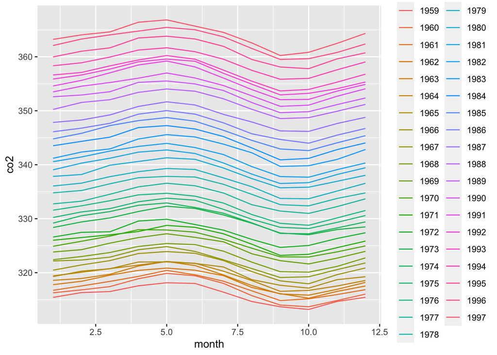

```r
co2_tidy$month <- as.numeric(co2_tidy$month)
co2_tidy |> ggplot(aes(month, co2, color = year)) + geom_line()
```

```r
str(co2_tidy)
```

```
## tibble [468 × 3] (S3: tbl_df/tbl/data.frame)
##  $ year : chr [1:468] "1959" "1959" "1959" "1959" ...
##  $ month: num [1:468] 1 2 3 4 5 6 7 8 9 10 ...
##  $ co2  : num [1:468] 315 316 316 318 318 ...
```

3. What do we learn from this plot? Probably b: CO2 measures are higher in the summer and have increased since 1959
4. If we think of an observation as a major, and that each observation has two variables (men admitted percentage and women admitted percentage) then this is not tidy. Use the pivot_wider function to wrangle into tidy shape: one row for each major.

```r
data(admissions) # the "load(admissions)" command didn't work for me
dat <- admissions |> select(-applicants)
dat |> pivot_wider(id_cols = major, names_from = gender, values_from = admitted) %>% head
```

```
## # A tibble: 6 × 3
##   major   men women
##   <chr> <dbl> <dbl>
## 1 A        62    82
## 2 B        63    68
## 3 C        37    34
## 4 D        33    35
## 5 E        28    24
## 6 F         6     7
```

5 - 8. Now we will try a more advanced wrangling challenge. We want to wrangle the admissions data so that for each major we have 4 observations: admitted_men, admitted_women, applicants_men and applicants_women. The trick we perform here is actually quite common: first use pivot_longer to generate an intermediate data frame and then pivot_wider to obtain the tidy data we want. We will go step by step in this and the next two exercises.

```r
admissions |> pivot_longer(cols = c("admitted", "applicants"),
                           values_to = "people", names_to = "applicants")  |>
              pivot_wider(id_cols = major, names_from = c(applicants,gender), values_from = people ) %>% head
```

```
## # A tibble: 6 × 5
##   major admitted_men applicants_men admitted_women applicants_women
##   <chr>        <dbl>          <dbl>          <dbl>            <dbl>
## 1 A               62            825             82              108
## 2 B               63            560             68               25
## 3 C               37            325             34              593
## 4 D               33            417             35              375
## 5 E               28            191             24              393
## 6 F                6            373              7              341
```

### 22.4 Exercises

1. We can see column names nameFirst and nameLast. Use the left_join function to create a table of the top home run hitters. The table should have playerID, first name, last name, and number of home runs (HR). Rewrite the object top with this new table.

```r
#install.packages("Lahman")
library(Lahman)

top <- Batting |>
  filter(yearID == 2016) |>
  arrange(desc(HR)) |>
  slice(1:10)

top |> as_tibble()
```

```
## # A tibble: 10 × 22
##    playerID  yearID stint teamID lgID      G    AB     R     H   X2B   X3B    HR
##    <chr>      <int> <int> <fct>  <fct> <int> <int> <int> <int> <int> <int> <int>
##  1 trumbma01   2016     1 BAL    AL      159   613    94   157    27     1    47
##  2 cruzne02    2016     1 SEA    AL      155   589    96   169    27     1    43
##  3 daviskh01   2016     1 OAK    AL      150   555    85   137    24     2    42
##  4 doziebr01   2016     1 MIN    AL      155   615   104   165    35     5    42
##  5 encared01   2016     1 TOR    AL      160   601    99   158    34     0    42
##  6 arenano01   2016     1 COL    NL      160   618   116   182    35     6    41
##  7 cartech02   2016     1 MIL    NL      160   549    84   122    27     1    41
##  8 frazito01   2016     1 CHA    AL      158   590    89   133    21     0    40
##  9 bryankr01   2016     1 CHN    NL      155   603   121   176    35     3    39
## 10 canoro01    2016     1 SEA    AL      161   655   107   195    33     2    39
## # ℹ 10 more variables: RBI <int>, SB <int>, CS <int>, BB <int>, SO <int>,
## #   IBB <int>, HBP <int>, SH <int>, SF <int>, GIDP <int>
```

```r
People |> as_tibble()
```

```
## # A tibble: 20,676 × 26
##    playerID  birthYear birthMonth birthDay birthCountry birthState birthCity
##    <chr>         <int>      <int>    <int> <chr>        <chr>      <chr>
##  1 aardsda01      1981         12       27 USA          CO         Denver
##  2 aaronha01      1934          2        5 USA          AL         Mobile
##  3 aaronto01      1939          8        5 USA          AL         Mobile
##  4 aasedo01       1954          9        8 USA          CA         Orange
##  5 abadan01       1972          8       25 USA          FL         Palm Beach
##  6 abadfe01       1985         12       17 D.R.         La Romana  La Romana
##  7 abadijo01      1850         11        4 USA          PA         Philadelphia
##  8 abbated01      1877          4       15 USA          PA         Latrobe
##  9 abbeybe01      1869         11       11 USA          VT         Essex
## 10 abbeych01      1866         10       14 USA          NE         Falls City
## # ℹ 20,666 more rows
## # ℹ 19 more variables: deathYear <int>, deathMonth <int>, deathDay <int>,
## #   deathCountry <chr>, deathState <chr>, deathCity <chr>, nameFirst <chr>,
## #   nameLast <chr>, nameGiven <chr>, weight <int>, height <int>, bats <fct>,
## #   throws <fct>, debut <chr>, finalGame <chr>, retroID <chr>, bbrefID <chr>,
## #   deathDate <date>, birthDate <date>
```

```r
# Sabrina's notes: always good idea to know the dimensions of the dfs you're joining
dim(top)
```

```
## [1] 10 22
```

```r
dim(People)
```

```
## [1] 20676    26
```

```r
# Note that top just has 10 entries. If we're left_joining to top, the resultant
# df should have 10 entries. We don't want something that has 20K entries.
# Before saving the join to the name space, check the resulting dims.
#
left_join(top, People) %>% dim # good news, still 10 rows, but lots more cols
```

```
## [1] 10 47
```

```r
top <- left_join(top, People)
```

2. Now use the Salaries data frame to add each player’s salary to the table you created in exercise 1. Note that salaries are different every year so make sure to filter for the year 2016, then use right_join. This time show first name, last name, team, HR, and salary.

```r
Salaries |>
  filter(yearID == 2016) |>
  right_join(top)  |>
  select(nameFirst, nameLast, teamID, HR, salary) # good idea to check dims before assigning
```

```
##    nameFirst    nameLast teamID HR   salary
## 1       Mark      Trumbo    BAL 47  9150000
## 2       Kris      Bryant    CHN 39   652000
## 3       Todd     Frazier    CHA 40  8250000
## 4      Nolan     Arenado    COL 41  5000000
## 5      Chris      Carter    MIL 41  2500000
## 6      Brian      Dozier    MIN 42  3000000
## 7      Khris       Davis    OAK 42   524500
## 8   Robinson        Cano    SEA 39 24000000
## 9     Nelson        Cruz    SEA 43 14250000
## 10     Edwin Encarnacion    TOR 42 10000000
```

3. In a previous exercise, we created a tidy version of the co2 dataset:

```r
co2_wide <- data.frame(matrix(co2, ncol = 12, byrow = TRUE)) |>
  setNames(1:12) |>
  mutate(year = 1959:1997) |>
  pivot_longer(-year, names_to = "month", values_to = "co2") |>
  mutate(month = as.numeric(month))
```

We want to see if the monthly trend is changing so we are going to remove the year effects and then plot the results. We will first compute the year averages. Use the group_by and summarize to compute the average co2 for each year. Save in an object called yearly_avg.

```r
head(co2_wide)
```

```
## # A tibble: 6 × 3
##    year month   co2
##   <int> <dbl> <dbl>
## 1  1959     1  315.
## 2  1959     2  316.
## 3  1959     3  316.
## 4  1959     4  318.
## 5  1959     5  318.
## 6  1959     6  318
```

```r
yearly_avg <- co2_wide |>
                group_by(year) |>
                summarize(av_co2 = mean(co2, na.rm = T))
```

4. Now use the left_join function to add the yearly average to the co2_wide dataset. Then compute the residuals: observed co2 measure - yearly average.

```r
co2_wide |> dim() # resultant df should be 468 long
```

```
## [1] 468   3
```

```r
left_join(co2_wide, yearly_avg) |> dim() #good, added 1 col
```

```
## [1] 468   4
```

```r
co2_wide <- left_join(co2_wide, yearly_avg) |>
  mutate(residuals = co2 - av_co2)
```

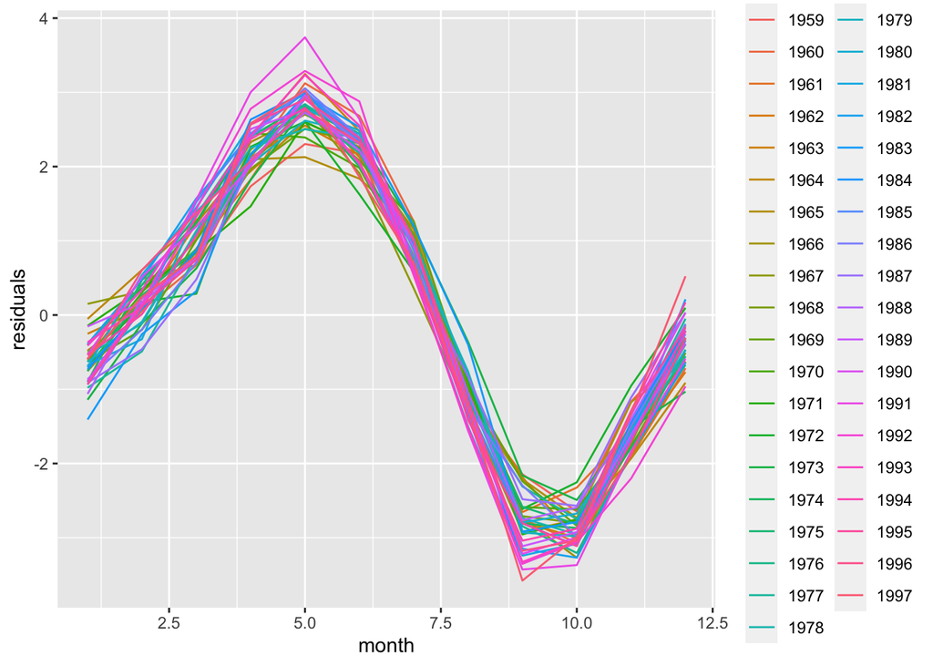

```r
co2_wide %>% ggplot(aes(x = month, y = residuals, col = as.character(year))) + geom_line()
```

```r
#Graph notes: at first it looked super wonky, I realized it was treating year
#as a continuous numeric variable, not a category.
```